...

```python
import pandas as pd
import numpy as np
import scipy.stats as stats
import matplotlib.pyplot as plt
from scipy.stats import spearmanr
from IPython.display import HTML

# function to display figures with formatting and caption
def display_figure(fig, fig_id, caption, w=0.6, fs=12):
    import io
    import base64
    plt.rcParams['figure.dpi'] = 300
    plt.rcParams['savefig.dpi'] = 300
    pic_IObytes = io.BytesIO()

    # set fontsize for title and labels
    for ax in fig.axes:
        text_items = [ax.title, ax.xaxis.label, ax.yaxis.label]
        if ax.get_legend() is not None:
            text_items = text_items + ax.get_legend().get_texts()
        for item in (text_items + ax.get_xticklabels() + ax.get_yticklabels() ):
            item.set_fontsize(fs)

    plt.savefig(pic_IObytes, format='png', bbox_inches='tight')
    pic_IObytes.seek(0)
    pic_hash = base64.b64encode(pic_IObytes.read())

    img = f'<img margin="auto" width="{w*100}%" src="data:… {str(pic_hash)[2:-1]}" />'
    caption = f'<figcaption style="text-align: center; font-style: italic;">{caption}</figcaption>'
    display(HTML(f'<br><fig width="100%" id={fig_id}><center>{img}</center> {caption}</fig><br>'))

    plt.close(fig)
```

# Investigating the Cognitive Tests

## Introduction

Human cognition is a complex and multifaceted ability that encompasses a wide range of cognitive processes, including perception, attention, memory, language, reasoning and problem-solving. These cognitive processes are essential for our ability to learn, adapt and thrive in our environment.

Approximate number system (ANS) (Odic D, Starr A (2018)) is a cognitive ability that allows individuals to approximate or estimate the quantity of a set without relying on counting or language. It is a fundamental aspect of human cognition, playing a crucial role in various domains, including mathematics, spatial reasoning and decision-making. Math ability is a crucial aspect of human cognition, playing a fundamental role in our ability to comprehend and manipulate numerical concepts. It underpins various essential skills, including counting, arithmetic and problem-solving. Memory is the ability to encode, store and retrieve information from our minds. It is a crucial cognitive ability that allows us to learn, remember past events, and make decisions. Lastly, spatial recognition is the ability to mentally manipulate and transform objects in a three-dimensional space. It is essential for a variety of tasks, including navigation and problem-solving.

In this study, we aim to further investigate the relationship between ANS and other cognitive abilities, specifically exploring its association with maths ability, spatial recognition, and memory. Additionally, we aim to examine whether there exists a significant difference in the scores of males and females across these cognitive tests.

### Hypotheses

Based on the available literature and our understanding of the cognitive tests, we propose the following hypotheses:

**A) Is ANS related to maths, spatial reasoning or memory skills?** We hypothesise that ANS may be positively correlated with maths performance(Justin Halberda et al. (2015)), suggesting that individuals with better ANS may exhibit superior mathematical abilities We also hypothesise that ANS may be positively correlated with spatial reasoning, indicating that individuals with enhanced ANS may demonstrate better spatial problem-solving skills. However, we think that the association between ANS and memory skills may be weaker, with ANS having a less direct role in memory processes.

**B) Can we detect any significant difference between the scores of males and females across our cognitive tests?** Based on previous studies, we hypothesise that there may be a modest gender difference in maths and memory (Upadhayay N, Guragain S (2014)), with males generally scoring higher than females. However, we anticipate that no significant difference in gender will be observed in spatial reasoning performance.

## Methods

This study was conducted within BIOS0030 23/24 class and the participants were all second year undergraduates from the Division of Biosciences at UCL. Ages of these participants ranged from 19 to 21 years old. The number of participants in each of these tests may vary upon individual preferences, with them having the autonomy to decide whether they wish to complete the tasks assigned by our professor. Prior to data upload to the Google Form for further analysis, a data disclaimer question sought permission from participants

Questions which involve increasing complexity were designed for each test – ANS, Maths Ability, Memory Test and Spatial Reasoning – to observe the performances of the participants as the difficulty of the task progressed. This approach aimed to provide information about their peak performance and the point at which cognitive abilities might start to decline or plateau. For instance, the complexity of maths questions increases as the user advances through the test, incorporating larger numbers and introducing multiplication and division in the calculations. The time taken to solve one problem is recorded to determine how long the user takes to process the transition from easy to medium to difficult problems.

The code for all four tests were first written in JupyterLab then uploaded onto GitHub for collaboration purposes among the group members. The test files were then uploaded onto JupyterLab so that it can be accessed and run by every student in the class. Scores and time taken to conduct each test were recorded and stored in Google form.

Statistical evaluation based on the test results, was performed by importing pandas, numpy, matplotlib and scipy.stats modules to Jupyterhub to allow plotting box plots, dot plots, histograms and scatter plots as well as calculating p-value for our test results.

## Results

The results obtained from cognitive tests were used to evaluate the hypothesis.

Hypothesis A was tested by comparing the ANS score to scores from other cognitive tests. This is achieved by making three scatter plots. Pearson correlation coefficient (r) and Spearman’s rank correlation coefficient were derived from these scatter plots to determine whether there is any significant positive correlation between ANS score and cognitive performance. Histogram plots are derived from each of the test results to identify and remove any potential problems in the data se The results are introduced below..

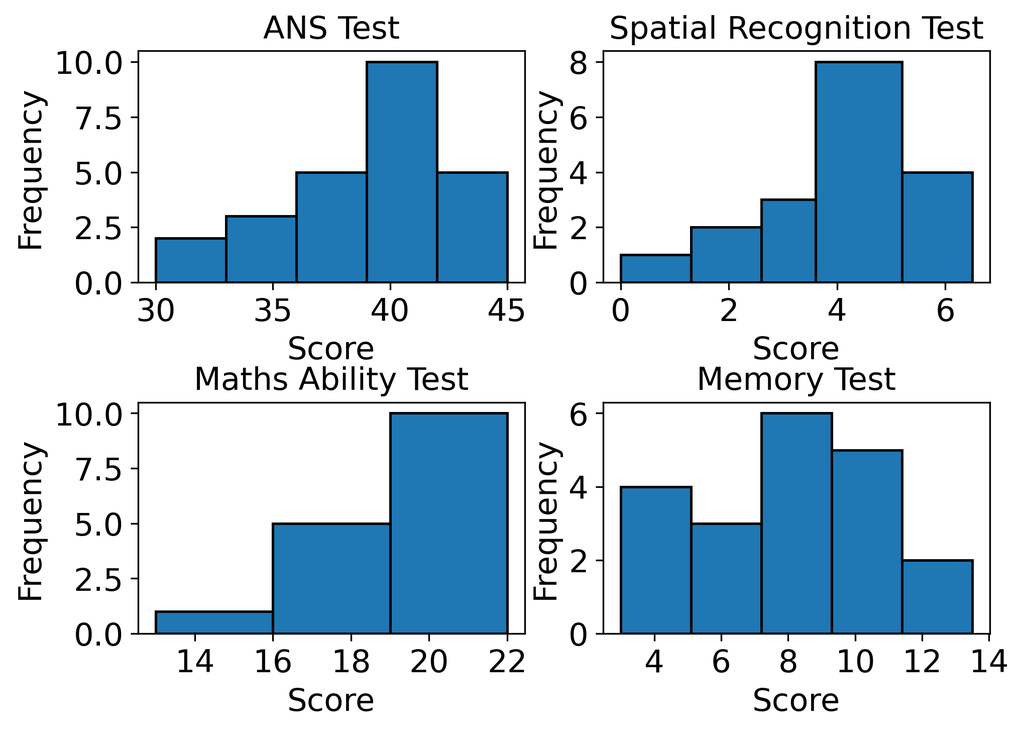

Figure 1: Histogram plot showing the distribution of cognitive test results

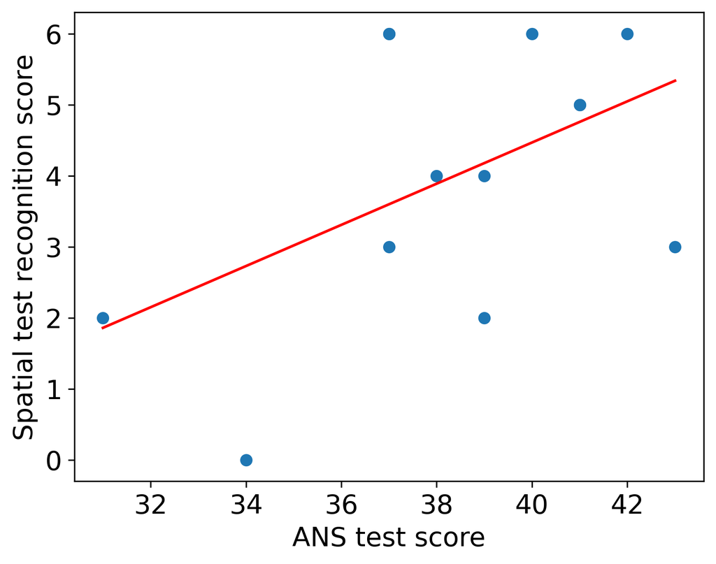

Figure 2: Scatter plot of ANS test score vs spatial recognition test score. The Pearson correlation coefficient (r) is 0.50

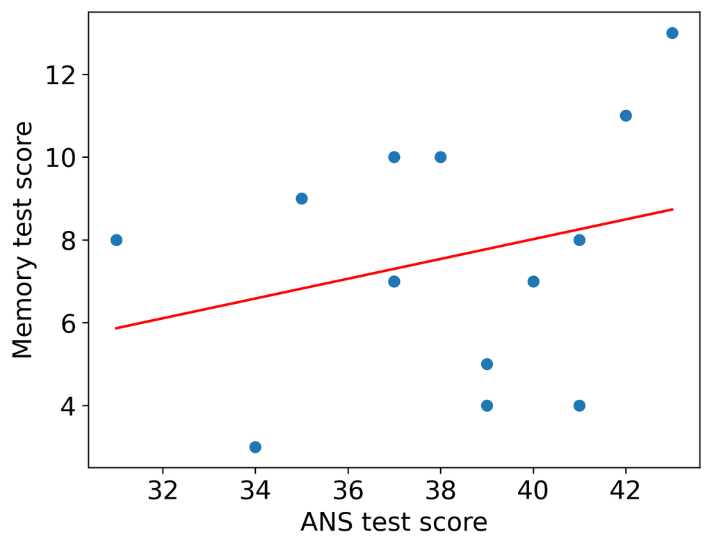

Figure 3: Scatter plot of ANS test socre vs memory test score. The r value is 0.27

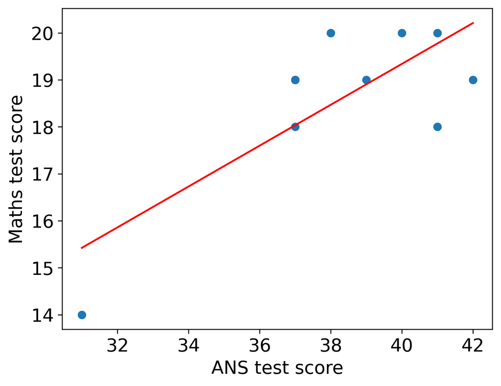

Figure 4: Scatter plot of ANS test socre vs maths test score. The r value is 0.77

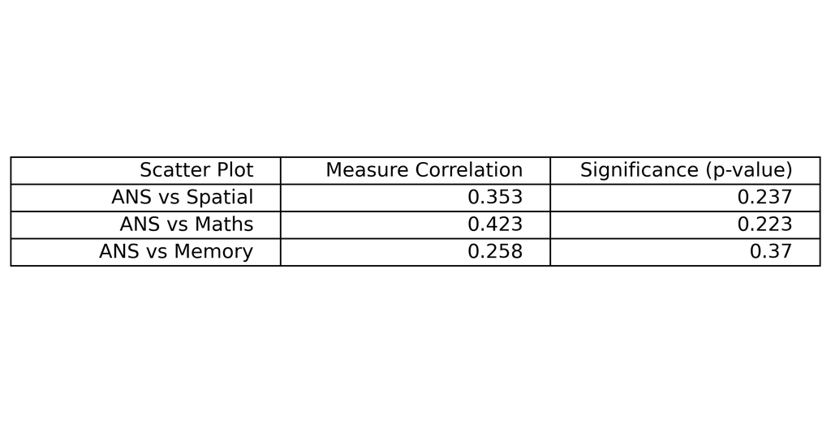

Figure 5: Table showing Spearman's rank value of each scatter plot and theri significance (p-value).

```python
result_1 = pd.read_csv("ANS vs Spatial.csv")
result_2 = pd.read_csv("ANS vs memory.csv")
result_3= pd.read_csv("ANS vs maths.csv")

math = pd.read_csv('math_ability_responses.csv')
memory = pd.read_csv('memory_test_responses.csv')
spat = pd.read_csv('spatial_recognition_responses.csv')
ans = pd.read_csv('ansrespclean.csv')

bina = [30, 33, 36, 39, 42, 45]
biny = [13, 16,19,22]
binz = [3.0, 5.1, 7.2, 9.3, 11.4, 13.5]
binx = [0, 1.3, 2.6, 3.6, 5.2, 6.5]

fig, axs = plt.subplots(2,2)

# Create a scatter plot for each feature in the data
axs[0, 0].hist(ans['score'], bins=bina, edgecolor = 'black', linewidth = 1.2)
axs[0, 1].hist(spat['score'], bins=binx, edgecolor = 'black', linewidth = 1.2)
axs[1, 0].hist(math['score'], bins=biny, edgecolor = 'black', linewidth = 1.2)
axs[1, 1].hist(memory['total_score'], bins=binz, edgecolor = 'black', linewidth = 1.2)

# Set the axis labels and title for each subplot
axs[0, 0].set_xlabel('Score')
axs[0, 0].set_ylabel('Frequency')
axs[0, 0].set_title('ANS Test')

axs[0, 1].set_xlabel('Score')
axs[0, 1].set_ylabel('Frequency')
axs[0, 1].set_title('Spatial Recognition Test')

axs[1, 0].set_xlabel('Score')
axs[1, 0].set_ylabel('Frequency')
axs[1, 0].set_title('Maths Ability Test')

axs[1, 1].set_xlabel('Score')
axs[1, 1].set_ylabel('Frequency')
axs[1, 1].set_title('Memory Test')

# using padding
fig.tight_layout(pad=1.0)

cap = "Figure 1: Histogram plot showing the distribution of cognitive test results"

display_figure(fig, "fig1", cap, w = 0.5, fs = 15)




fig= plt.figure()
ax = fig.add_subplot()
x=result_1['x']
y=result_1['y']

plt.scatter(x,y)
slope, intercept = np.polyfit(x, y, 1)
x_line = np.array([min(x), max(x)])
y_line = slope * x_line + intercept

plt.plot(x_line,y_line,color="red")

r_value = np.corrcoef(x, y)[0, 1]

plt.xlabel('ANS test score')
plt.ylabel('Spatial test recognition score')


cap = "Figure 2: Scatter plot of ANS test score vs spatial recognition test score. The Pearson correlation coefficient (r) is 0.50"
display_figure(fig, "fig2",cap, w=0.3, fs=15)


fig= plt.figure()
ax = fig.add_subplot()
x=result_2['y']
y=result_2['x']

plt.scatter(x,y)
slope, intercept = np.polyfit(x, y, 1)
x_line = np.array([min(x), max(x)])
y_line = slope * x_line + intercept

plt.plot(x_line,y_line,color="red")

r_value = np.corrcoef(x, y)[0, 1]

plt.xlabel('ANS test score')
plt.ylabel('Memory test score')


cap = "Figure 3: Scatter plot of ANS test socre vs memory test score. The r value is 0.27 "
display_figure(fig, "fig3",cap, w=0.3, fs=15)

fig= plt.figure()
ax = fig.add_subplot()
x=result_3['y']
y=result_3['x']

plt.scatter(x,y)
slope, intercept = np.polyfit(x, y, 1)
x_line = np.array([min(x), max(x)])
y_line = slope * x_line + intercept

plt.plot(x_line,y_line,color="red")

r_value = np.corrcoef(x, y)[0, 1]
plt.xlabel('ANS test score')
plt.ylabel('Maths test score')


cap = "Figure 4: Scatter plot  of ANS test socre vs maths test score. The r value is 0.77 "
display_figure(fig, "fig4",cap, w=0.3, fs=15)


fig, ax = plt.subplots()
data = [['Scatter Plot','Measure Correlation','Significance (p-value)'],
        ['ANS vs Spatial', 0.353, 0.237],
        ['ANS vs Maths', 0.423, 0.223],
        ['ANS vs Memory',0.258,0.370]]

table = ax.table(cellText=data, loc='center')
table.set_fontsize(14)
table.scale(1.5, 1.5)
ax.axis('off')






cap = "Figure 5: Table showing Spearman's rank value of each scatter plot and theri significance (p-value)."
display_figure(fig, "fig5",cap, w=0.5, fs=15)
```

Hypothesis B was validated by using t-tests. The t-tests analysed the significance of the difference in average scores between the male and female participants in various cognitive tests. Box plots were also created using the test results from each test conducted by different genders. The box plots were used to recognise any anomalies in the data.

The results are presented below.

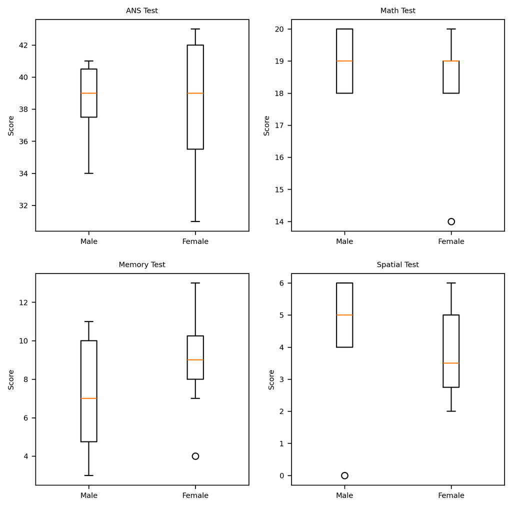

Figure 6 :Box Plot for all tests

```python
filename = "ans_responses.csv"
ans_df = pd.read_csv(filename)

filename = "math_ability_responses.csv"
maths_df = pd.read_csv(filename)

filename = "memory_test_responses.csv"
memory_df = pd.read_csv(filename)

filename = "spatial_recognition_responses.csv"
sr_df = pd.read_csv(filename)


ans_male_scores = ans_df[ans_df['gender']=='M']['score']
ans_female_scores = ans_df[ans_df['gender']=='F']['score']

maths_male_scores = maths_df[maths_df['gender'] == 'male']['score']
maths_female_scores = maths_df[maths_df['gender'] == 'female']['score']

memory_male_scores = memory_df[memory_df['gender']=='Male']['total_score']
memory_female_scores = memory_df[memory_df['gender']=='Female']['total_score']

sr_male_scores = sr_df[sr_df['sex'] == 'male']['score']
sr_female_scores = sr_df[sr_df['sex'] == 'female']['score']

#show all 4 box plots in a figure

fig, ax = plt.subplots(2,2)

#create a box plot for ANS
ax[0,0].boxplot([ans_male_scores, ans_female_scores], labels = ['Male','Female'])

#create a box plot for math
ax[0,1].boxplot([maths_male_scores, maths_female_scores], labels = ['Male','Female'])

#create a box plot for memory
ax[1,0].boxplot([memory_male_scores, memory_female_scores], labels = ['Male','Female'])

#create a box plot for spatial
ax[1,1].boxplot([sr_male_scores, sr_female_scores], labels = ['Male','Female'])

#set labels and title
ax[0,0].title.set_text("ANS Test")
ax[0,0].set_ylabel('Score')

ax[0,1].title.set_text("Math Test")
ax[0,1].set_ylabel('Score')

ax[1,0].title.set_text("Memory Test")
ax[1,0].set_ylabel('Score')

ax[1,1].title.set_text("Spatial Test")
ax[1,1].set_ylabel('Score')

fig.set_size_inches([8,8])

#display box plots

caption = "Figure 6 :Box Plot for all tests"
fig_id = "fig6"

display_figure(fig, "fig6", caption, 0.9, 7)
```

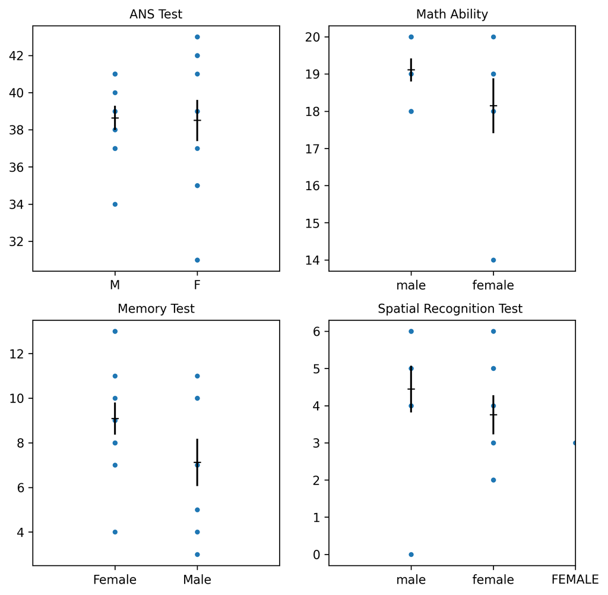

Figure 7: Comparison of Males vs Females mean scores for all tests.

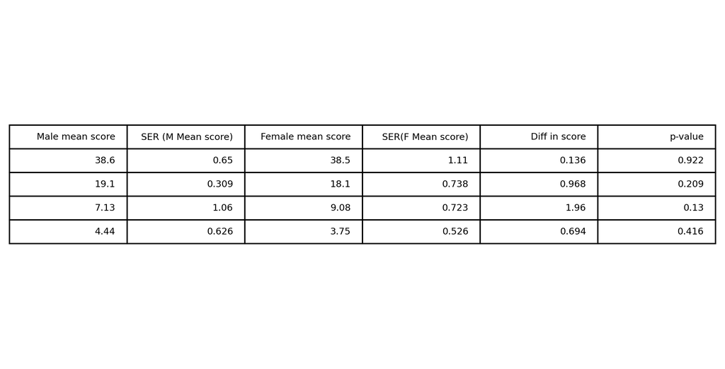

Figure 8: Table comprised of the mean score, the SER, the difference in score and p-value of the two genders.

```python
fig = plt.figure(figsize=(8,8))

#ANS (1)
ans_male_scores = ans_df[ans_df['gender'] == 'M']['score']
ans_female_scores = ans_df[ans_df['gender'] == 'F']['score']

#plot dot graph
ax1 = fig.add_subplot(2,2,1)
ax1.plot(ans_df['gender'],ans_df['score'],'.')
#x-axis limits for 2 categories
#range from 0 to 1
#adjust for nicer spacing
ax1.set_xlim(-1,2)

#score categorised by gender
ans_male_df = ans_male_scores
ans_female_df = ans_female_scores

#mean
ans_male_mean = ans_male_df.mean()
ans_female_mean = ans_female_df.mean()

#standard_error of both gender
ans_male_std_error = stats.sem(ans_male_df)
ans_female_std_error = stats.sem(ans_female_df)

#draw the mean with error bars
ax1.errorbar('M', ans_male_mean, yerr= ans_male_std_error, marker='_', color='black',label='Mean ± Std dev')
ax1.errorbar('F', ans_female_mean, yerr= ans_female_std_error, marker='_', color='black')

ax1.set_title("ANS Test")

#MATH ABILITY (2)
#male and female score pulled out from data
male_scores = maths_df[maths_df['gender'] == 'male']['score']
female_scores = maths_df[maths_df['gender'] == 'female']['score']

#plot dot graph
ax2 = fig.add_subplot(2,2,2)
ax2.plot(maths_df['gender'],maths_df['score'],'.')
#x-axis limits for 2 categories
#range from 0 to 1
#adjust for nicer spacing
ax2.set_xlim(-1,2)

#score categorised by gender
m_df = male_scores
f_df = female_scores

#mean
m_mean = m_df.mean()
f_mean = f_df.mean()

#standard_error of both gender
m_std_error = stats.sem(m_df)
f_std_error = stats.sem(f_df)

#draw the mean with error bars
ax2.errorbar('male', m_mean, yerr=m_std_error, marker='_', color='black',label='Mean ± Std dev')
ax2.errorbar('female', f_mean, yerr=f_std_error, marker='_', color='black')

ax2.set_title("Math Ability")

#MEMORY TEST (3)
#male and female score pulled out from data
memory_male_scores = memory_df[memory_df['gender'] == 'Male']['total_score']
memory_female_scores = memory_df[memory_df['gender'] == 'Female']['total_score']

#plot dot graph
ax3 = fig.add_subplot(2,2,3)

ax3.plot(memory_df['gender'],memory_df['total_score'],'.')
#x-axis limits for 2 categories
#range from 0 to 1
#adjust for nicer spacing
ax3.set_xlim(-1,2)

#score categorised by sex
memory_m_df = memory_male_scores
memory_f_df = memory_female_scores

#mean
memory_m_mean = memory_m_df.mean()
memory_f_mean = memory_f_df.mean()

#standard_error of both sex
memory_m_std_error = stats.sem(memory_m_df)
memory_f_std_error = stats.sem(memory_f_df)

#draw the mean with error bars
ax3.errorbar('Male', memory_m_mean, yerr=memory_m_std_error, marker='_', color='black')
ax3.errorbar('Female', memory_f_mean, yerr=memory_f_std_error, marker='_', color='black')

ax3.set_title("Memory Test")

#SPATIAL REASONING (4)
#male and female score pulled out from data
male_scores = sr_df[sr_df['sex'] == 'male']['score']
female_scores = sr_df[sr_df['sex'] == 'female']['score']

#plot dot graph
ax4 = fig.add_subplot(2,2,4)

ax4.plot(sr_df['sex'],sr_df['score'],'.')
#x-axis limits for 2 categories
#range from 0 to 1
#adjust for nicer spacing
ax4.set_xlim(-1,2)

#score categorised by sex
m_df = male_scores
f_df = female_scores

#mean
m_mean = m_df.mean()
f_mean = f_df.mean()

#standard_error of both sex
m_std_error = stats.sem(m_df)
f_std_error = stats.sem(f_df)

#draw the mean with error bars
ax4.errorbar('male', m_mean, yerr=m_std_error, marker='_', color='black')
ax4.errorbar('female', f_mean, yerr=f_std_error, marker='_', color='black')

ax4.set_title("Spatial Recognition Test ")

caption = "Figure 7: Comparison of Males vs Females mean scores for all tests."

display_figure(fig, "fig7", caption, 0.6, 10)


fig, ax = plt.subplots()
data = [['Male mean score','SER (M Mean score)','Female mean score','SER(F Mean score)','Diff in score','p-value'],
        [38.60,0.650,38.50,1.110,0.136,0.922],
        [19.10,0.309,18.10,0.738,0.968,0.209],
         [7.13,1.060,9.08,0.723,1.960,0.130],
         [4.44,0.626,3.75,0.526,0.694,0.416]]

table = ax.table(cellText=data, loc='center')
table.set_fontsize(14)
table.scale(1.5, 1.5)
ax.axis('off')

cap = "Figure 8: Table comprised of the mean score, the SER, the difference in score and p-value of the two genders."
display_figure(fig,"fig8",cap, w=0.7, fs=15)
```

The histogram plot in Figure 1 showed that there are two potential outliers with in the data collected. One in the maths ability test and one in the spatial recognition test. They are both present on the left side of the plot. These outliers are further verified by the box plots in Figure 6. The box plot also showed that there is another outlier in the memory test.

The scatter plots Figure 2, Figure 3 and Figure 4 all showed positive correlation between ANS score and test scores of other cognitive tests. This is shown by the Pearson correlation coefficient, where the maths test score shows the strongest correlation (r=0.77) and memory test score being the lowest (r=0.27). To evaluate the significance of the correlation, Spearman's rank calculations were carried out on each of the test results. The Spearman’s rank calculation presented in Figure 5 showed that there is no significance in the positive correlation between the test scores.

## Discussion

From the data collected, comparison could be made between ANS and the other cognitive tests to investigate whether there are any relations between them. From previous studies, it was shown that ANS correlates with mathematical ability. Children with a good number representation are better mathematically. There are also studies done where spatial factors could influence a person’s numerosity perception(Marco Ziegler et al. (2023)). Although a positive correlation can be seen from our results, the p-values (Figure 5) for both ANS vs maths test and ANS vs spatial recognition test were found to be 0.223 and 0.237, respectively. ANS and memory was found to have the weakest correlation with a value of 0.258 and a p-value of 0.370. This means that, in our study, there are no significant relationship found between these tests hence there is not enough evidence to accept the hypothesis that they are related. These values could be attributed to the fact that there is only a small amount of data collected so it is not representative towards the general population.

The second hypothesis that was investigated was whether there are any significant difference in scores between male and female across the cognitive tests. From the dot plots, mean score for the memory test is higher in females than male. Interestingly, it is reversed for spatial recognition and maths test. However, the mean score for ANS test are similar between the two groups. From the results, t-test was done to obtain the p-values shown in Figure 8 for each tests to compare between the two groups and it was found that there are no significant difference between them across our cognitive tests. This coincides with previous researches where there are no significant difference between the groups in cognitive ability.

In future researches, this test can be improved with larger data set so that the results and comparison between tests could be more representative towards the general population. These cognitive tests can be used as a guidline towards people's numerical, spacial and memory. This is important to understand the population's ability based on individual's education level, geographical and within different demographics.

## Bibliography

Justin Halberda, Darko Odic (2015) Chapter 12 - The Precision and Internal Confidence of Our Approximate Number Thoughts. Volume 1, 2015, Pages 305-333  
[Odic D, Starr A (2018)](https://www.ncbi.nlm.nih.gov/pmc/articles/PMC6286047/) An Introduction to the Approximate Number System. Child Dev Perspect. 2018 Dec;12(4):223-229.  
[Upadhayay N, Guragain S (2014)](https://www.ncbi.nlm.nih.gov/pmc/articles/PMC4129348/) Comparison of cognitive functions between male and female medical students: a pilot study. J Clin Diagn Res. 2014 Jun;8(6):BC12-5.  
[Ziegler, M.C., Stricker, L.K. & Drewing, K. (2023)](https://link.springer.com/article/10.3758/s13414-023-02658-9) The role of spatial information in an approximate cross-modal number matching task. Atten Percept Psychophys 85, 1253–1266 (2023).